# Case Study - Machine Learning in R

8/15/2017

## Introduction

## What We'll Do This Afternoon

- Introducing basic machine learning methods
- Form hypothesis for machine learning
- Continue wrangling the data for machine learning
- Implement some ML in R

## Why Machine Learning?

- Prediction
- Pattern recognition
- Interpretation and diagnosis
- Make some money on

[figure not shown]

## Examples

- Risk prediction for cancer
- IBM Watson
- Image recognition
- Netflix recommender system

## Machine Learning in R

- Many other languages can do ML (Matlab, Python, Julia, etc.)
- R bridges statistics and machine learning
- Active community developing and updating packages constantly (11265 packages)!

[figure not shown]

- Powerful data manipulation and graphics tools as you saw earlier

## Types of machine learning

- Supervised learning: learn a function to map predictor variables (\(\mathbf{X}\)) to response variables (\(\mathbf{Y}\))
  - Linear models
  - SVM, CART, random forest
  - Neural networks
- Unsupervised learning: learn the structure of data points
  - Clustering (k-means, hierarchical clustering)
  - Anomaly detection
- Semi-supervised learning

## Model selection and evaluation

- Model evaluation
  - Perform on a separate set (train/test split)
  - Regression: \(R^2\), MSE
  - Classification: Accuracy, confusion table, AUC
- Model selection
  - Cross validation (train/validation/test split)
  - Selection criterion

## Case Study - Regression

## Read in the data

- Read in the data and format the *price* as a numeric:

```r
listings = read.csv("../data/listings.csv",stringsAsFactors = FALSE)
library(tidyverse)
listings = listings %>% mutate(price = as.numeric(gsub("\\$|,","",price)))
```

## Example visualization

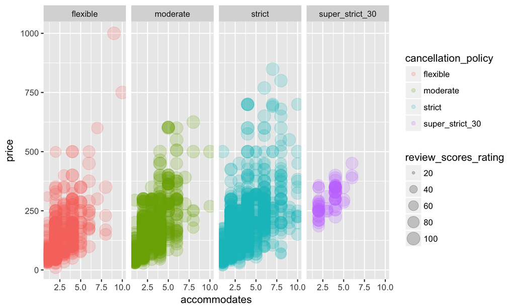

```r
listings_for_lm = listings %>%
  filter(accommodates <= 10, price <=1000)
ggplot(listings_for_lm)+
  aes(x=accommodates, y=price, color=cancellation_policy, size=review_scores_rating)+
  geom_point(alpha = 0.2)+
  facet_wrap(~cancellation_policy,ncol=4)
```

## First linear model

Given data \(X_t\) and \(y_t\), linear regression solves the following problem: \[ \min_\beta \sum_{t=1}^n (y_t-x_t^T\beta)^2, \]  
which is also known as **ordinary least square** regression since it minimizes the sum of squared errors.

## First linear model

- Before running the model, recall we need to split the data first:

```r
library(modelr)
listings_part = listings_for_lm %>%
  resample_partition(c(train=0.7,test=0.3))
```

- Use the lm command. Example:

```r
lm_price_by_acc = lm(price ~ accommodates,data=listings_part$train)
```

## Look at model summary

```r
summary(lm_price_by_acc)
```

```
##
## Call:
## lm(formula = price ~ accommodates, data = listings_part$train)
##
## Residuals:
##     Min      1Q  Median      3Q     Max
## -287.87  -56.04  -18.84   38.96  905.77
##
## Coefficients:
##              Estimate Std. Error t value Pr(>|t|)
## (Intercept)    55.427      3.892   14.24   <2e-16 ***
## accommodates   37.806      1.155   32.74   <2e-16 ***
## ---
## Signif. codes:  0 '***' 0.001 '**' 0.01 '*' 0.05 '.' 0.1 ' ' 1
##
## Residual standard error: 93.45 on 2490 degrees of freedom
## Multiple R-squared:  0.301,  Adjusted R-squared:  0.3007
## F-statistic:  1072 on 1 and 2490 DF,  p-value: < 2.2e-16
```

## Exercise 2: Evaluating first model

- How would you visualize the model fit? Spend 10 minutes to come up with your visualizations
- Some hints:
  - You can use `as.data.frame()` to convert a resample object such as `listings_part$train` to a data frame
  - `add_predictions()` function from `modelr` package might be useful
  - `add_residuals()` can be useful too

## Quantify first model performance

- Root Mean-squared Error (RMSE): \(\sqrt{\sum_{t=1}^n (\hat{y}_t - y_t)^2/n}\)
- Mean Absolute Error (MAE): \(\sum_{t=1}^n |\hat{y}_t - y_t|/n\)
- Coefficient of determination (R2): \(1-\frac{\sum_{t=1}^n (\hat{y}_t - y_t)^2}{\sum_{t=1}^n (\bar{y}_t - y_t)^2}\)
  - \(\hat{y}_t\) is the predicted value for observation \(t\)
  - \(y_t\) is the actual value
  - \(\bar{y}_t\) is the mean value
- Pay attention to *in-sample* vs. *out-of-sample*!

## You can get them easily with `modelr`

```r
rmse(lm_price_by_acc,listings_part$test)
```

```
## [1] 91.5668
```

```r
mae(lm_price_by_acc,listings_part$test)
```

```
## [1] 66.97742
```

```r
rsquare(lm_price_by_acc,listings_part$test)
```

```
## [1] 0.3502389
```

## Summary of procedure

1. We asked the questions: How does listing price depend on the number of people it accommodates? How well does accommodation size predict price?
2. Since we were interested in prediction, we reserved part of our data as a test set.
3. We then chose to use a linear model to answer these questions, and found the corresponding function `lm()`, which takes:
   1. Data on the response and predictor variables, usually through a `formula` object
   2. Model parameters (in the case of `lm()`, we used all the default values)

## Summary of procedure

1. `R` then automatically found the "best" linear model by computing the least squares estimate, and returned a `lm` object, which was a list including information about
   1. Fitted coefficients
   2. Residuals
   3. Statistical significance
   4. …

## Add more variables

- We can build more interesting model formulas in `R`:
  - Predictors are separated with a `+`
  - Use `.` on the right-hand side to include all predictors in a given data frame
  - Use `.-x` to include all predictors except `x`
  - To include interactions between variables, use the `*` symbol. For example: `y ~ x + z + x*z`
  - To exclude the intercept term, include `-1` or `+0` on the right-hand side
- For more detailed info, see [documentation on R formula](https://stat.ethz.ch/R-manual/R-devel/library/stats/html/formula.html)

## Add more variables

- Inspect the "amenities" column. Need some data cleaning to make it useful!
- Run the cleaning code included in the script.

## Exercise 2: Build your next model

- Work with your partner, build your next linear model with multiple variables.
  - Clean the data first if necessary (remove missing observations, etc.)
  - Remember the formula syntax
  - Use some of the amenity variables we just created
  - Consider interactions and transformation of variables
  - Don't forget to do the train/test split
- Generate model performance measures and compare with our first model
- Visualize data and results

## Example model

[output not shown]

## LASSO

- When a model overfits, we can add a term to the optimization problem that we're solving when fitting a model
  - the term penalizes models that get too fancy without enough data
- Recall our classical linear regression looks like \[ \min_\beta \sum_{t=1}^n (y_t-x_t^T\beta)^2, \]
- penalized regression looks like  
  \[ \min_\beta \sum_{t=1}^n (y_t-x_t^T\beta)^2 + \lambda ||\beta||. \]

## LASSO

- Two natural choices of norm are the Euclidean 1- and 2-norms:
  - 2-norm: "ridge regression"
  - 1-norm: "LASSO regression"
- Both types shrink all the elements of the unconstrained \(\beta\) vector towards zero, some more than others in a special way. LASSO shrinks the coefficients so that some are equal to zero.
- LASSO is incredibly popular, cited by 20,000+ papers!
- To do LASSO, we'll use the `glmnet` package.

## LASSO

- The syntax is a bit different:

```r
library(glmnet)
x = model.matrix(~ .-price + accommodates*room_type + property_type*neighbourhood_cleansed + review_scores_rating*neighbourhood_cleansed + accommodates*review_scores_rating,data=as.data.frame(listings_big_lm$train))
y = as.vector(as.data.frame(listings_big_lm$train)$price)
lasso_price = glmnet(x,y)
```

## LASSO - interpret outputs

Running `glmnet` gives the results for a range of \(\lambda\) values. We can take a closer look at one:

```r
lasso_price$lambda[20]
```

```
## [1] 11.33284
```

```r
lasso_price$beta[which(lasso_price$beta[,20] != 0),20]
```

```
##                                 room_typePrivate room
##                                          -34.87856694
##                        neighbourhood_cleansedBack Bay
##                                            4.80412787
##                     neighbourhood_cleansedBeacon Hill
##                                            0.07989603
##                                        amenity_TVTRUE
##                                            3.51200835
##                  amenity_Free_Parking_on_PremisesTRUE
##                                           -5.37052440
##                          amenity_Air_ConditioningTRUE
##                                            5.27968566
##                          amenity_Indoor_FireplaceTRUE
##                                            2.67169998
##                                  amenity_Cable_TVTRUE
##                                           10.55546037
##                      amenity_Elevator_in_BuildingTRUE
##                                           12.88875248
##                    accommodates:room_typePrivate room
##                                           -7.57608901
## review_scores_rating:neighbourhood_cleansedDorchester
##                                           -0.03457500
##                     accommodates:review_scores_rating
##                                            0.25171490
```

## LASSO - interpret outputs

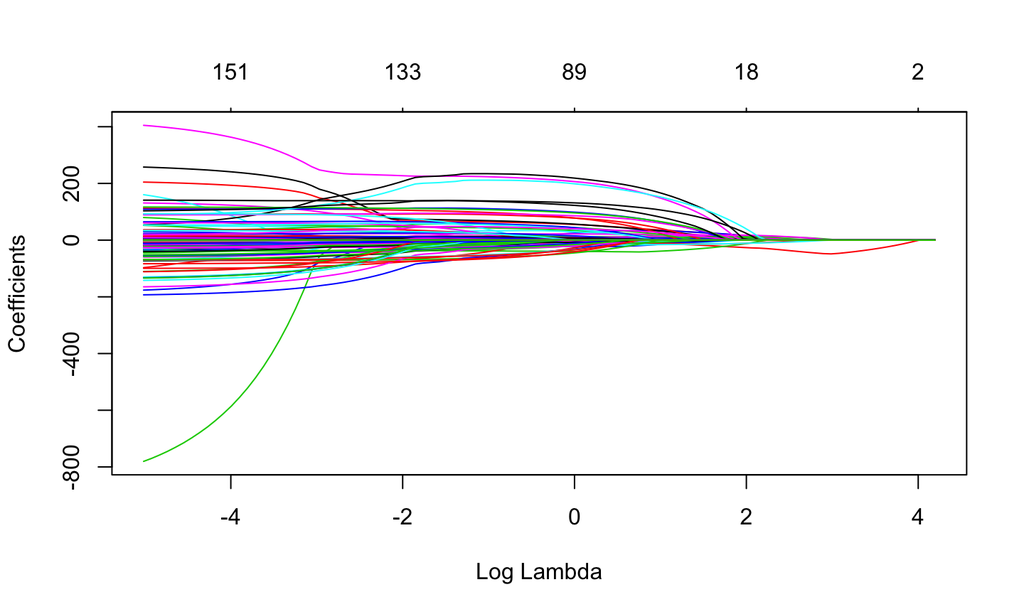

```r
plot.glmnet(lasso_price,xvar="lambda")
```

- Each line is one variable. As lambda shrinks, the model adds more and more nonzero coefficients.

## Cross Validation

- We just trained many models, but should not choose one by comparing their performance in test set (why?)
- But we can do cross-validation
  - Only train on some of the training
  - Save the rest of training to evaluate (validation set)
  - A final test set to evaluate performance once we've settled on a model
- More economic way to use data: *k-fold cross-validation*
  - Divide the training data into groups called *folds*
  - For each fold repeat the train-validate procedure
  - Average the performance of each model on each fold and pick the best one.
- A common *resampling* method.

## Cross Validation, Illustrated

[figure not shown]

## Cross Validation in Action

The glmnet package has a very handy function called `cv.glmnet()` which does the entire process automatically.

- The relevant arguments are:
  - x, the matrix of predictors
  - y, the response variable
  - nfolds, the number of ways to split the training set (defaults to 10)
  - type.measure, the metric of prediction quality. It defaults to mean squared error, the square of RMSE, for linear regression

## Cross Validation in Action

```r
lasso_price_cv = cv.glmnet(x,y)
lasso_price_cv$lambda.min
```

```
## [1] 0.9192414
```

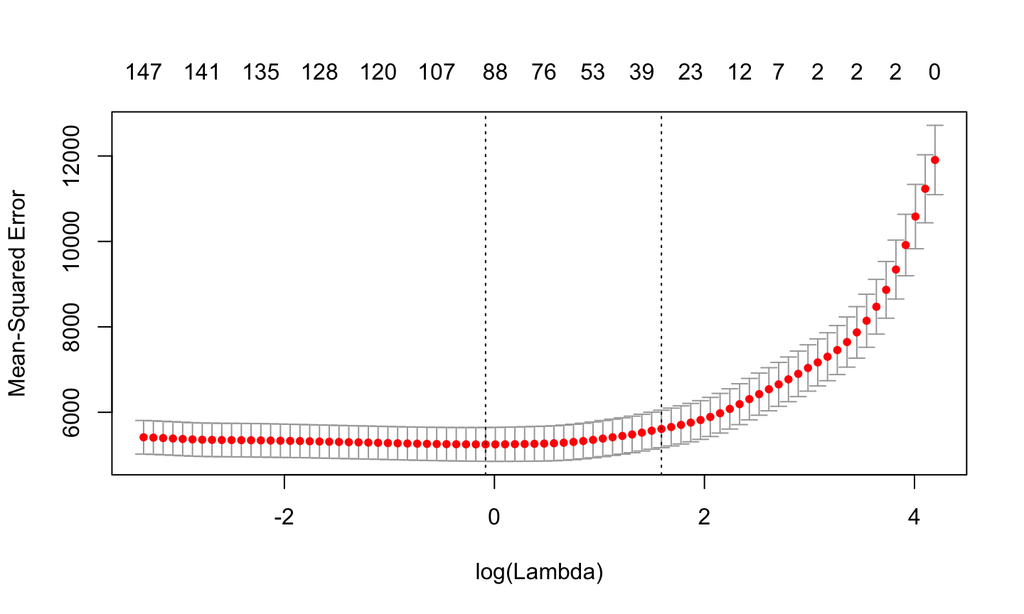

```r
plot.cv.glmnet(lasso_price_cv)
```

## Evaluate Cross Validated Model

```r
lasso.pred = predict.cv.glmnet(lasso_price_cv,newx=x_all, s="lambda.min")

listings_big %>%
  mutate(is_test = 1:nrow(listings_big) %in% listings_big_lm$test$idx,
         pred = lasso.pred) %>%
  group_by(is_test) %>%
  summarize(rmse = sqrt(1/length(price)*sum((price-pred)^2)))
```

```
## # A tibble: 2 x 2
##   is_test     rmse
##     <lgl>    <dbl>
## 1   FALSE 66.65230
## 2    TRUE 72.85325
```

## Case Study - Classification

## Logistic Regression

- Part of the class of generalized linear models (GLMs)
- These models take the linear fit and map it through a non-linear function.
- For logistic regression, it uses the logistic function \(f(x) = \frac{e^x}{1+e^x}\), which looks like this:

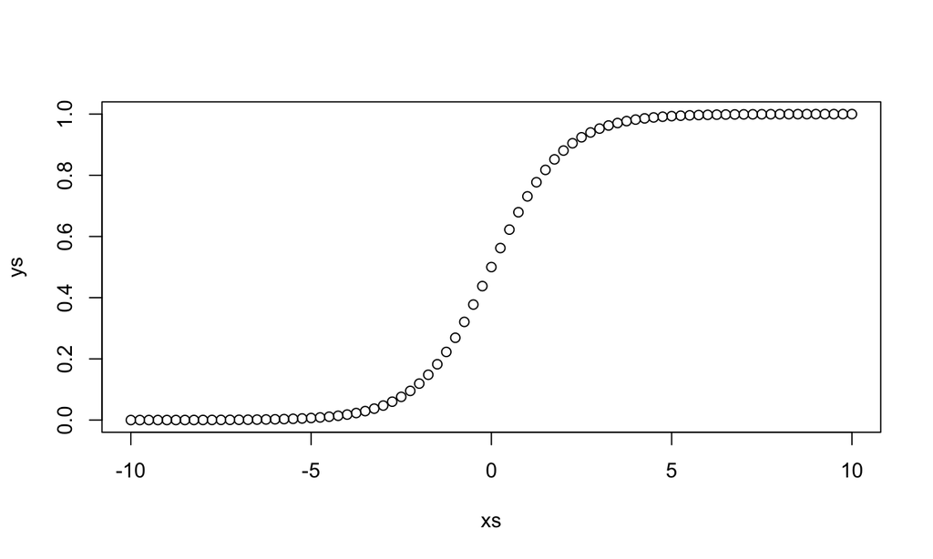

## Logistic Regression in R

The syntax is similar to linear regression, with `binomial` for the family parameter.

```
l.glm = glm(y ~ x,family="binomial",data=mydata$train)
summary(l.glm)
```

## Exercise 4: Generating Hypotheses

- Now think about a binary variable that you might find interesting to predict
- Come up with a model to explain the variable

## Classification Evaluation

Classification problems are evaluated by - Accuracy - True positive rate - False positive rate - … - Area under the curve

## Classification Evaluation

As the cutoff shrinks down from 1 to 0, the rate of total positives will increase.

## Additional Resources

- [R for Data Science](http://r4ds.had.co.nz/), an online book on modeling via r’s `tidyverse` package.
- [The Elements of Statistical Learning](https://web.stanford.edu/~hastie/ElemStatLearn), by Hastie, Tibshirani, and Friedman
- MIT courses, including
- 15.680 (Machine Learning: Algorithms, Applications, and Computation),
- 15.071 (“The Analytics Edge”, an application and coding-based analytics course),
- 6.867 (EECS’s introductory Machine Learning course)
- 9.520 (A theory course about regularized machine learning methods)

## The End

Special thanks to Clark Pixton, Colin Pawlowski, and Jerry Kung for previous course materials.